# Yeast Genome Analysis: Summary of Findings

Bioinformatics Team

# Executive Summary

This report summarizes the genetic effects of four experimental treatments (WT, WTA, STC, and CAS) on the genome of *Saccharomyces cerevisiae* (baker’s yeast). Through whole-genome sequencing and variant analysis, we have identified distinct mutation patterns that provide insight into how each treatment affects DNA integrity.

**Key Findings:**

1. **Each treatment creates a unique “genetic signature”** with characteristic mutation patterns
2. **Mutations are highly clustered** (71-84%) rather than randomly distributed throughout the genome
3. **Treatment effects target specific genomic regions**, particularly scaffold JRIU01000031.1
4. **CAS treatment shows a remarkably specific mutation mechanism** (100% transition mutations)
5. **WT and WTA treatments show complementary mutation patterns** (G→A vs. A→G) suggesting related but opposite effects

## What This Means

These findings suggest the treatments are affecting specific DNA repair or replication mechanisms rather than causing random damage. The high degree of clustering indicates that certain genomic regions are particularly vulnerable to the effects of these treatments.

# Understanding Mutation Patterns

## Mutation Types Explained

For non-specialists, DNA mutations can be classified into two main categories:

**Transitions:** Changes between similar bases: - A → G or G → A (purine to purine) - C → T or T → C (pyrimidine to pyrimidine)

**Transversions:** Changes between dissimilar bases: - A → C, A → T, G → C, or G → T (purine to pyrimidine) - C → A, C → G, T → A, or T → G (pyrimidine to purine)

Transitions typically occur more frequently in nature and often result from specific biological processes like deamination. Transversions generally require more substantial chemical changes to the DNA.

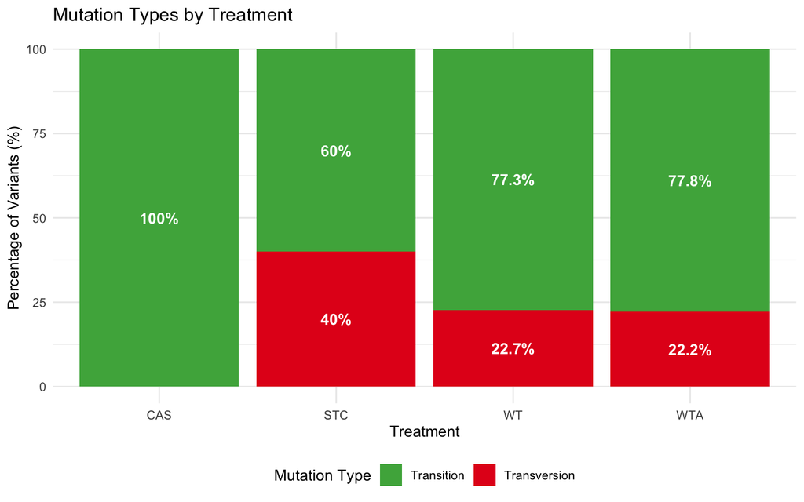

Transitions vs. transversions across treatments. CAS shows exclusively transition mutations.

## Mutation Clustering

One of our most striking findings is that mutations are not randomly distributed across the genome. Instead, they occur in clusters, with 71-84% of mutations located within 10 base pairs of another mutation.

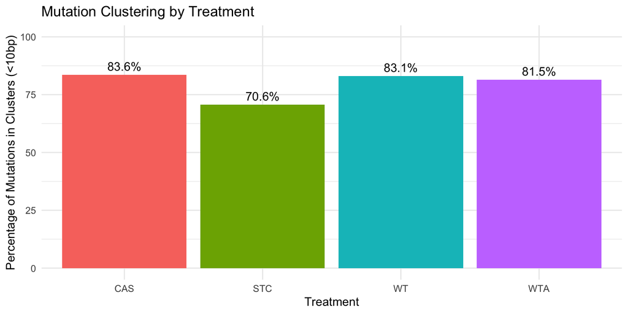

Percentage of variants found in clusters across treatments.

# Treatment-Specific Effects

Each treatment produces a characteristic mutation pattern that provides clues about its biological effects:

Summary of treatment-specific effects

| Treatment | % Clustered | % Transitions | Top Mutation | % of Top Mutation | Hotspot Scaffold |
| --- | --- | --- | --- | --- | --- |
| WT | 83.1 | 77.27273 | G>A | 45.45455 | JRIU01000157.1 |
| STC | 70.6 | 60.00000 | A>C | 20.00000 | JRIU01000117.1 |
| CAS | 83.6 | 100.00000 | C>T | 40.00000 | JRIU01000289.1 |
| WTA | 81.5 | 77.77778 | A>G | 55.55556 | JRIU01000341.1 |

## CAS Treatment

The CAS treatment shows a remarkably specific effect on the yeast genome:

- **100% transition mutations** — a highly unusual pattern indicating a very specific DNA repair defect
- **High clustering** (83.6%) — mutations are tightly grouped
- **C→T bias** (40% of mutations) — consistent with cytosine deamination or defective repair of this specific mutation type

These characteristics suggest CAS might specifically affect pathways that repair cytosine deamination damage, such as components of the base excision repair system.

## WT Treatment

The WT treatment shows:

- **Strong G→A bias** (45.5% of mutations)
- **High clustering** (83.1%)
- Targets a different hotspot (JRIU01000157.1) than other treatments

This pattern is typically associated with oxidative damage to guanine bases, which can form 8-oxoguanine that pairs with adenine instead of cytosine during DNA replication.

## WTA Treatment

Interestingly, WTA treatment shows:

- **Strong A→G bias** (55.6%) — the complement of WT’s dominant mutation pattern
- **High clustering** (81.5%)
- **Similar transition percentage** to WT (77.8% vs. 77.3%)

The complementary mutation pattern suggests that WTA’s “modification A” might affect similar biological pathways as WT but with an effect on the opposite DNA strand.

## STC Treatment

STC treatment shows the most diverse mutation profile:

- **Lowest clustering** (70.6%)
- **Most balanced mutation spectrum** with highest transversion rate (40%)
- No strongly dominant mutation type

This suggests STC may disrupt multiple DNA repair pathways simultaneously or cause more generalized genomic instability.

# Hotspot Analysis

All treatments show particular vulnerability in specific genomic regions, especially scaffold JRIU01000031.1.

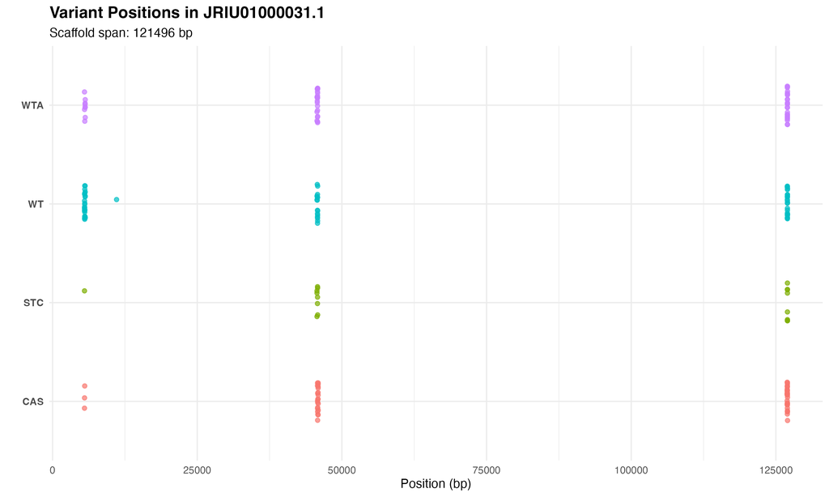

Position of variants in JRIU01000031.1 across treatments

Reasons why certain regions might be more susceptible to mutation include:

1. **DNA secondary structures** that challenge replication machinery
2. **Sequence context** such as repeats or homopolymer runs
3. **Late replication timing** which can reduce repair efficiency
4. **Functional importance** of the region to cellular processes